# IS 6812 Exploratory Data Analysis

Georgia Christodoulou

10/6/2024

```r
knitr::opts_chunk$set(warning = FALSE, message = FALSE)
```

# 1 Business Statement and Analytic Problems

Home Credit provides a safe and trustworthy loan experience for those with insufficient or non-existent credit histories. Since Home Credit uses alternative data to determine if a client can repay their loan, Home Credit wants to ensure that they are not rejecting clients that are capable of repayment and to set these clients up for success. However, current models might not fully use the available data leading to missed opportunities and can potentially lead to excluding deserving individuals from a loan or giving approved individuals payment terms that they fail to follow. In this stage, we will explore the existing and missing data and explore potential predictor variables to better predict if a client will default on their loan or not.

# 2 Questions To Think About

- How much of the data is missing?
- Do the variables with a lot of missing data seem like they could be valuable in predicting default?
- What should we do with the variable that have missing data?
- How many variables could help in predicting default?
- Are there any categorical variables that could be helping in predicting default?

# 3 Libraries and Data Import

```r
library(tidyverse)
library(dbplyr)
library(skimr)
library(janitor)
library(psych)

homecredit_train <- read.csv("C:/Users/GeorgiaChristodoulou/Desktop/Practice Capstone Fall 2024/application_train.csv", stringsAsFactors = TRUE)
homecredit_test <- read.csv("C:/Users/GeorgiaChristodoulou/Desktop/Practice Capstone Fall 2024/application_test.csv", stringsAsFactors = TRUE)
bureau <- read.csv("C:/Users/GeorgiaChristodoulou/Desktop/Practice Capstone Fall 2024/bureau.csv", stringsAsFactors = TRUE)

# factorize target variable
homecredit_train$TARGET <- factor(homecredit_train$TARGET)

# view summary of training data
homecredit_train %>% summary()
```

```
##    SK_ID_CURR     TARGET           NAME_CONTRACT_TYPE CODE_GENDER  FLAG_OWN_CAR
##  Min.   :100002   0:282686   Cash loans     :278232   F  :202448   N:202924
##  1st Qu.:189146   1: 24825   Revolving loans: 29279   M  :105059   Y:104587
##  Median :278202                                       XNA:     4
##  Mean   :278181
##  3rd Qu.:367143
##  Max.   :456255
##
##  FLAG_OWN_REALTY  CNT_CHILDREN     AMT_INCOME_TOTAL      AMT_CREDIT
##  N: 94199        Min.   : 0.0000   Min.   :    25650   Min.   :  45000
##  Y:213312        1st Qu.: 0.0000   1st Qu.:   112500   1st Qu.: 270000
##                  Median : 0.0000   Median :   147150   Median : 513531
##                  Mean   : 0.4171   Mean   :   168798   Mean   : 599026
##                  3rd Qu.: 1.0000   3rd Qu.:   202500   3rd Qu.: 808650
##                  Max.   :19.0000   Max.   :117000000   Max.   :4050000
##
##   AMT_ANNUITY     AMT_GOODS_PRICE          NAME_TYPE_SUITE
##  Min.   :  1616   Min.   :  40500   Unaccompanied  :248526
##  1st Qu.: 16524   1st Qu.: 238500   Family         : 40149
##  Median : 24903   Median : 450000   Spouse, partner: 11370
##  Mean   : 27109   Mean   : 538396   Children       :  3267
##  3rd Qu.: 34596   3rd Qu.: 679500   Other_B        :  1770
##  Max.   :258026   Max.   :4050000                  :  1292
##  NA's   :12       NA's   :278       (Other)        :  1137
##              NAME_INCOME_TYPE                     NAME_EDUCATION_TYPE
##  Working             :158774   Academic degree              :   164
##  Commercial associate: 71617   Higher education             : 74863
##  Pensioner           : 55362   Incomplete higher            : 10277
##  State servant       : 21703   Lower secondary              :  3816
##  Unemployed          :    22   Secondary / secondary special:218391
##  Student             :    18
##  (Other)             :    15
##             NAME_FAMILY_STATUS           NAME_HOUSING_TYPE
##  Civil marriage      : 29775   Co-op apartment    :  1122
##  Married             :196432   House / apartment  :272868
##  Separated           : 19770   Municipal apartment: 11183
##  Single / not married: 45444   Office apartment   :  2617
##  Unknown             :     2   Rented apartment   :  4881
##  Widow               : 16088   With parents       : 14840
##
```

[output cut: 241 more lines]

```
##  Min.   :0.00               Min.   : 0.00             Min.   :  0.00
##  1st Qu.:0.00               1st Qu.: 0.00             1st Qu.:  0.00
##  Median :0.00               Median : 0.00             Median :  0.00
##  Mean   :0.03               Mean   : 0.27             Mean   :  0.27
##  3rd Qu.:0.00               3rd Qu.: 0.00             3rd Qu.:  0.00
##  Max.   :8.00               Max.   :27.00             Max.   :261.00
##  NA's   :41519              NA's   :41519             NA's   :41519
##  AMT_REQ_CREDIT_BUREAU_YEAR
##  Min.   : 0.0
##  1st Qu.: 0.0
##  Median : 1.0
##  Mean   : 1.9
##  3rd Qu.: 3.0
##  Max.   :25.0
##  NA's   :41519
```

```r
# view structure of test data
homecredit_test %>% summary()
```

```
##    SK_ID_CURR           NAME_CONTRACT_TYPE CODE_GENDER FLAG_OWN_CAR
##  Min.   :100001   Cash loans     :48305    F:32678     N:32311
##  1st Qu.:188558   Revolving loans:  439    M:16066     Y:16433
##  Median :277549
##  Mean   :277797
##  3rd Qu.:367556
##  Max.   :456250
##
##  FLAG_OWN_REALTY  CNT_CHILDREN     AMT_INCOME_TOTAL    AMT_CREDIT
##  N:15086         Min.   : 0.0000   Min.   :  26942   Min.   :  45000
##  Y:33658         1st Qu.: 0.0000   1st Qu.: 112500   1st Qu.: 260640
##                  Median : 0.0000   Median : 157500   Median : 450000
##                  Mean   : 0.3971   Mean   : 178432   Mean   : 516740
##                  3rd Qu.: 1.0000   3rd Qu.: 225000   3rd Qu.: 675000
##                  Max.   :20.0000   Max.   :4410000   Max.   :2245500
##
##   AMT_ANNUITY     AMT_GOODS_PRICE          NAME_TYPE_SUITE
##  Min.   :  2295   Min.   :  45000   Unaccompanied  :39727
##  1st Qu.: 17973   1st Qu.: 225000   Family         : 5881
##  Median : 26199   Median : 396000   Spouse, partner: 1448
##  Mean   : 29426   Mean   : 462619                  :  911
##  3rd Qu.: 37391   3rd Qu.: 630000   Children       :  408
##  Max.   :180576   Max.   :2245500   Other_B        :  211
##  NA's   :24                         (Other)        :  158
##              NAME_INCOME_TYPE                    NAME_EDUCATION_TYPE
##  Businessman         :    1   Academic degree              :   41
##  Commercial associate:11402   Higher education             :12516
##  Pensioner           : 9273   Incomplete higher            : 1724
##  State servant       : 3532   Lower secondary              :  475
##  Student             :    2   Secondary / secondary special:33988
##  Unemployed          :    1
##  Working             :24533
##             NAME_FAMILY_STATUS           NAME_HOUSING_TYPE
##  Civil marriage      : 4261    Co-op apartment    :  123
##  Married             :32283    House / apartment  :43645
##  Separated           : 2955    Municipal apartment: 1617
##  Single / not married: 7036    Office apartment   :  407
##  Widow               : 2209    Rented apartment   :  718
##                                With parents       : 2234
##
```

[output cut: 225 more lines]

```
##  Min.   :0.000             Min.   :0.000              Min.   :0.000
##  1st Qu.:0.000             1st Qu.:0.000              1st Qu.:0.000
##  Median :0.000             Median :0.000              Median :0.000
##  Mean   :0.002             Mean   :0.003              Mean   :0.009
##  3rd Qu.:0.000             3rd Qu.:0.000              3rd Qu.:0.000
##  Max.   :2.000             Max.   :2.000              Max.   :6.000
##  NA's   :6049              NA's   :6049               NA's   :6049
##  AMT_REQ_CREDIT_BUREAU_QRT AMT_REQ_CREDIT_BUREAU_YEAR
##  Min.   :0.000             Min.   : 0.000
##  1st Qu.:0.000             1st Qu.: 0.000
##  Median :0.000             Median : 2.000
##  Mean   :0.547             Mean   : 1.984
##  3rd Qu.:1.000             3rd Qu.: 3.000
##  Max.   :7.000             Max.   :17.000
##  NA's   :6049              NA's   :6049
```

```r
# view summary of bureau data
bureau %>% summary()
```

```
##    SK_ID_CURR      SK_ID_BUREAU      CREDIT_ACTIVE       CREDIT_CURRENCY
##  Min.   :100001   Min.   :5000000   Active  : 630607   currency 1:1715020
##  1st Qu.:188867   1st Qu.:5463954   Bad debt:     21   currency 2:   1224
##  Median :278055   Median :5926304   Closed  :1079273   currency 3:    174
##  Mean   :278215   Mean   :5924434   Sold    :   6527   currency 4:     10
##  3rd Qu.:367426   3rd Qu.:6385681
##  Max.   :456255   Max.   :6843457
##
##   DAYS_CREDIT    CREDIT_DAY_OVERDUE  DAYS_CREDIT_ENDDATE DAYS_ENDDATE_FACT
##  Min.   :-2922   Min.   :   0.0000   Min.   :-42060.0    Min.   :-42023
##  1st Qu.:-1666   1st Qu.:   0.0000   1st Qu.: -1138.0    1st Qu.: -1489
##  Median : -987   Median :   0.0000   Median :  -330.0    Median :  -897
##  Mean   :-1142   Mean   :   0.8182   Mean   :   510.5    Mean   : -1017
##  3rd Qu.: -474   3rd Qu.:   0.0000   3rd Qu.:   474.0    3rd Qu.:  -425
##  Max.   :    0   Max.   :2792.0000   Max.   : 31199.0    Max.   :     0
##                                      NA's   :105553      NA's   :633653
##  AMT_CREDIT_MAX_OVERDUE CNT_CREDIT_PROLONG AMT_CREDIT_SUM
##  Min.   :        0      Min.   :0.00000    Min.   :        0
##  1st Qu.:        0      1st Qu.:0.00000    1st Qu.:    51300
##  Median :        0      Median :0.00000    Median :   125518
##  Mean   :     3825      Mean   :0.00641    Mean   :   354995
##  3rd Qu.:        0      3rd Qu.:0.00000    3rd Qu.:   315000
##  Max.   :115987185      Max.   :9.00000    Max.   :585000000
##  NA's   :1124488                           NA's   :13
##  AMT_CREDIT_SUM_DEBT AMT_CREDIT_SUM_LIMIT AMT_CREDIT_SUM_OVERDUE
##  Min.   : -4705600   Min.   :-586406      Min.   :      0
##  1st Qu.:        0   1st Qu.:      0      1st Qu.:      0
##  Median :        0   Median :      0      Median :      0
##  Mean   :   137085   Mean   :   6230      Mean   :     38
##  3rd Qu.:    40154   3rd Qu.:      0      3rd Qu.:      0
##  Max.   :170100000   Max.   :4705600      Max.   :3756681
##  NA's   :257669      NA's   :591780
##                         CREDIT_TYPE      DAYS_CREDIT_UPDATE  AMT_ANNUITY
##  Consumer credit              :1251615   Min.   :-41947.0   Min.   :        0
##  Credit card                  : 402195   1st Qu.:  -908.0   1st Qu.:        0
##  Car loan                     :  27690   Median :  -395.0   Median :        0
##  Mortgage                     :  18391   Mean   :  -593.8   Mean   :    15713
##  Microloan                    :  12413   3rd Qu.:   -33.0   3rd Qu.:    13500
##  Loan for business development:   1975   Max.   :   372.0   Max.   :118453424
##  (Other)                      :   2149                      NA's   :1226791
```

# 4 Discussing the Data

We have a variety of data sources including the application data of the individuals our outcomes, credit bureau data which provides us with previous loan history, data on if an individual previously applied for and received a loan from Home Credit, and others. In these data sources, we have several variables such as, employment type, education type, family size, gender, living situation, relationship status, loan amount, debt amount, how long a loan has been overdue, and much more. However, there is quite a bit of missing data in these data sets, most importantly the credit scores coming from external source 1 in the application data. There are a lot of normalized variables with information around living situations such as entrances, floors, elevators, apartments, and more that have quite a bit of missing data but because these do not seem relevant to if a client will default on their loan, we can remove these variable all together. However when we look at the credit score variables, we want to be careful with how we handle these. Since we are missing 173,378 values from external source 1, we cannot remove all rows with missing data because we would lose half of our data. We will need to decide if we will impute data or remove this column all together, and in this case, I will replace all missing values in all external credit sources with 0. Since this data is missing, we can assume that there is not a credit score from this source for that individual, so we can replace it with a 0. If this does not seem to be the right approach after completing the data exploration, we can take a different approach.

# 5 Explore Target Variable and Accuracy

```r
# counts of default and no default observations
homecredit_train %>% pull(TARGET) %>% table()
```

```
## .
##      0      1
## 282686  24825
```

```r
# proportions of default and no default observations
homecredit_train %>% pull(TARGET) %>% table() %>% prop.table() %>% round(2)
```

```
## .
##    0    1
## 0.92 0.08
```

The target variable, default or no default, is very unbalanced. The majority class classifier would always predict class 0, no default, leading to an accuracy of 92%.

# 6 Exploring Numeric Variables

## 6.1 Correlations

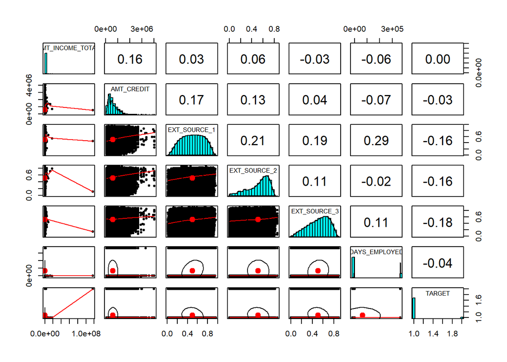

```r
# visual of correlations for some numeric variables with respect to the target variable
homecredit_train %>%
  select(AMT_INCOME_TOTAL,AMT_CREDIT,EXT_SOURCE_1,EXT_SOURCE_2,EXT_SOURCE_3, DAYS_EMPLOYED,TARGET) %>%
  pairs.panels()
```

The credit scores from external sources have the strongest correlations (negative) with respect to the target variable, implying that these could be useful predictors at this stage of the EDA. Additionally, the loan amount is correlated with an individuals income which could be valuable in determining loan amount to avoid default.

## 6.2 Numeric Variable Exploration - Income

```r
# income summary statistics
homecredit_train$AMT_INCOME_TOTAL %>%
  summary()
```

```
##      Min.   1st Qu.    Median      Mean   3rd Qu.      Max.
##     25650    112500    147150    168798    202500 117000000
```

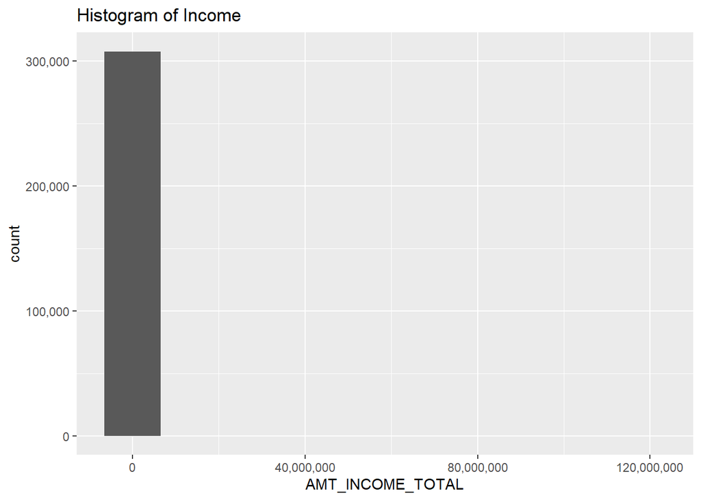

```r
# income histogram
homecredit_train %>%
  ggplot(aes(x=AMT_INCOME_TOTAL)) +
  geom_histogram(bins=10) +
  scale_x_continuous(labels = scales::comma) +
  scale_y_continuous(labels = scales::comma) +
  ggtitle('Histogram of Income')
```

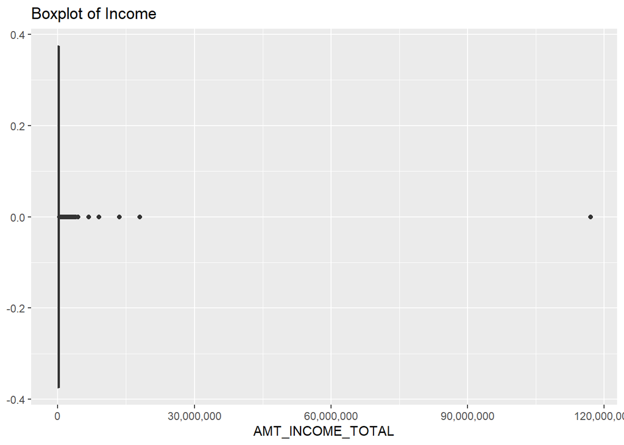

```r
# income boxplot
homecredit_train %>%
  ggplot(aes(x=AMT_INCOME_TOTAL)) +
  geom_boxplot() +
  scale_x_continuous(labels = scales::comma) +
  scale_y_continuous(labels = scales::comma) +
  ggtitle('Boxplot of Income')
```

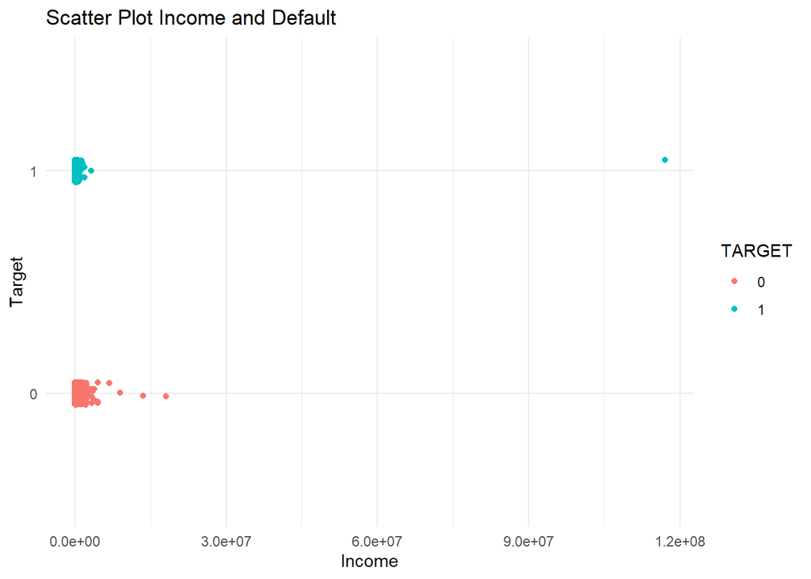

```r
# income vs. default scatterplot
homecredit_train %>%
  ggplot(aes(x = AMT_INCOME_TOTAL, y = TARGET, color = TARGET)) +
  geom_jitter(height = 0.05, width = 0.05) +
  labs(x = "Income", y = "Target") +
  theme_minimal() +
  ggtitle("Scatter Plot Income and Default")
```

There are some extreme values that don’t just seem like outliers that could be affecting the distribution of income. Additionally, it seems that those who default are more clustered around a much lower income, whereas those who don’t default are more spread out. Are these incomes all in the same currency? If they are, are they accurate? If we remove these values, could this variable be a better predictor of default? How much would the mean income change?

## 6.3 Numeric Variable Exploration - Credit Amount

```r
# credit amount summary statistics
homecredit_train$AMT_CREDIT %>%
  summary()
```

```
##    Min. 1st Qu.  Median    Mean 3rd Qu.    Max.
##   45000  270000  513531  599026  808650 4050000
```

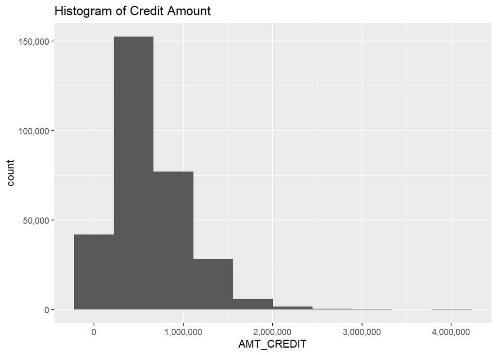

```r
# credit amount histogram
homecredit_train %>%
  ggplot(aes(x=AMT_CREDIT)) +
  geom_histogram(bins=10) +
  scale_x_continuous(labels = scales::comma) +
  scale_y_continuous(labels = scales::comma) +
  ggtitle('Histogram of Credit Amount')
```

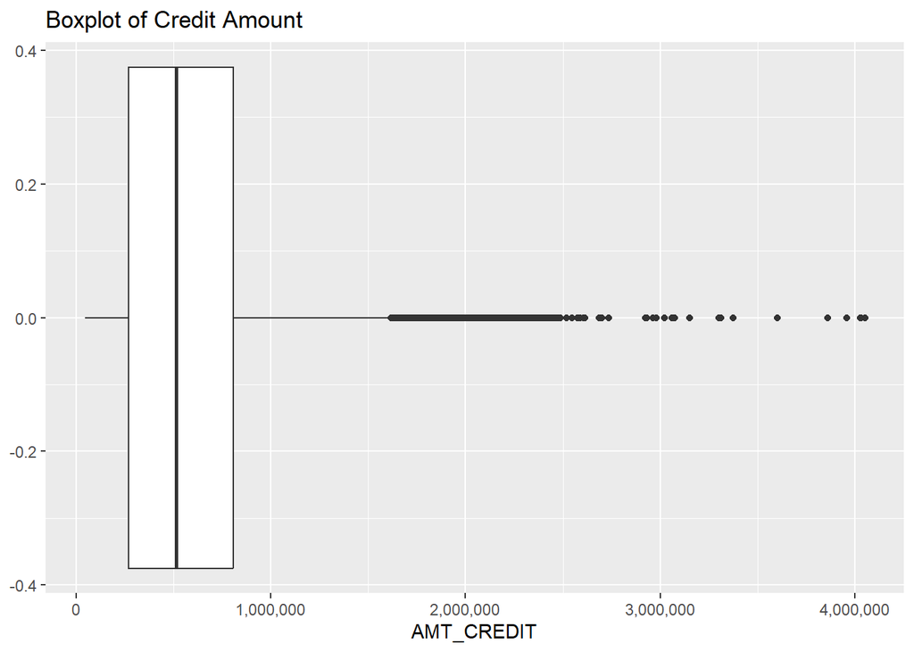

```r
# credit amount boxplot
homecredit_train %>%
  ggplot(aes(x=AMT_CREDIT)) +
  geom_boxplot() +
  scale_x_continuous(labels = scales::comma) +
  scale_y_continuous(labels = scales::comma) +
  ggtitle('Boxplot of Credit Amount')
```

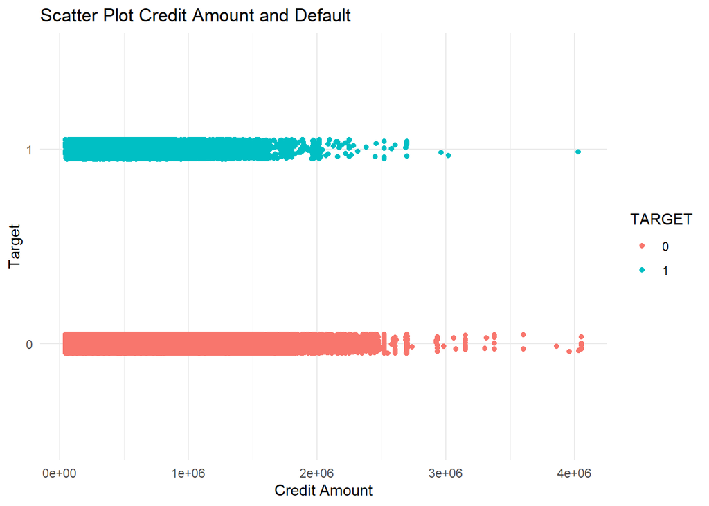

```r
# credit amount vs. default scatterplot
homecredit_train %>%
  ggplot(aes(x = AMT_CREDIT, y = TARGET, color = TARGET)) +
  geom_jitter(height = 0.05, width = 0.05) +
  labs(x = "Credit Amount", y = "Target") +
  theme_minimal() +
  ggtitle("Scatter Plot Credit Amount and Default")
```

The credit amount is more spread a bit more normally distributed, but still skewed. It seems that those who default received a lower loan amount, whereas those who don’t default are more spread out across various loan amounts.

## 6.4 Numeric Variable Exploration - Ext_Source_1

```r
# credit source 1 summary statistics
homecredit_train$EXT_SOURCE_1 %>%
  summary()
```

```
##    Min. 1st Qu.  Median    Mean 3rd Qu.    Max.    NA's
##    0.01    0.33    0.51    0.50    0.68    0.96  173378
```

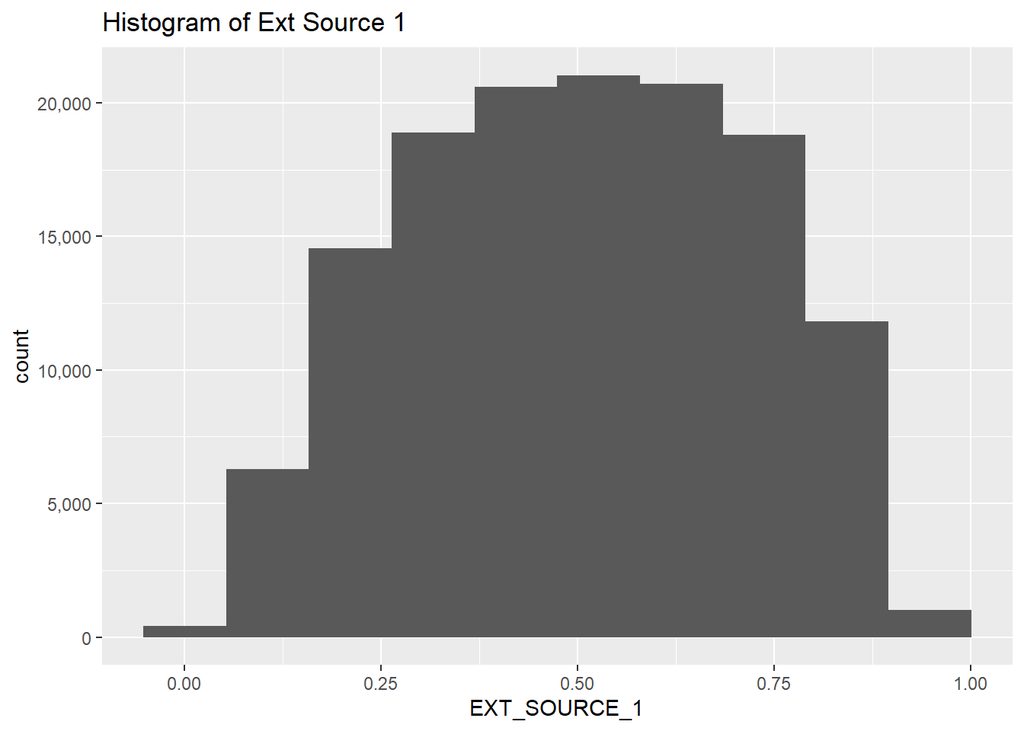

```r
# credit source 1 histogram
homecredit_train %>%
  ggplot(aes(x=EXT_SOURCE_1)) +
  geom_histogram(bins=10) +
  scale_x_continuous(labels = scales::comma) +
  scale_y_continuous(labels = scales::comma) +
  ggtitle('Histogram of Ext Source 1')
```

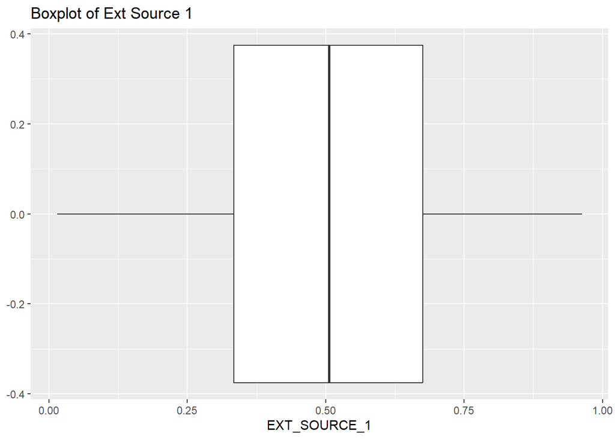

```r
# credit source 1 boxplot
homecredit_train %>%
  ggplot(aes(x=EXT_SOURCE_1)) +
  geom_boxplot() +
  scale_x_continuous(labels = scales::comma) +
  scale_y_continuous(labels = scales::comma) +
  ggtitle('Boxplot of Ext Source 1')
```

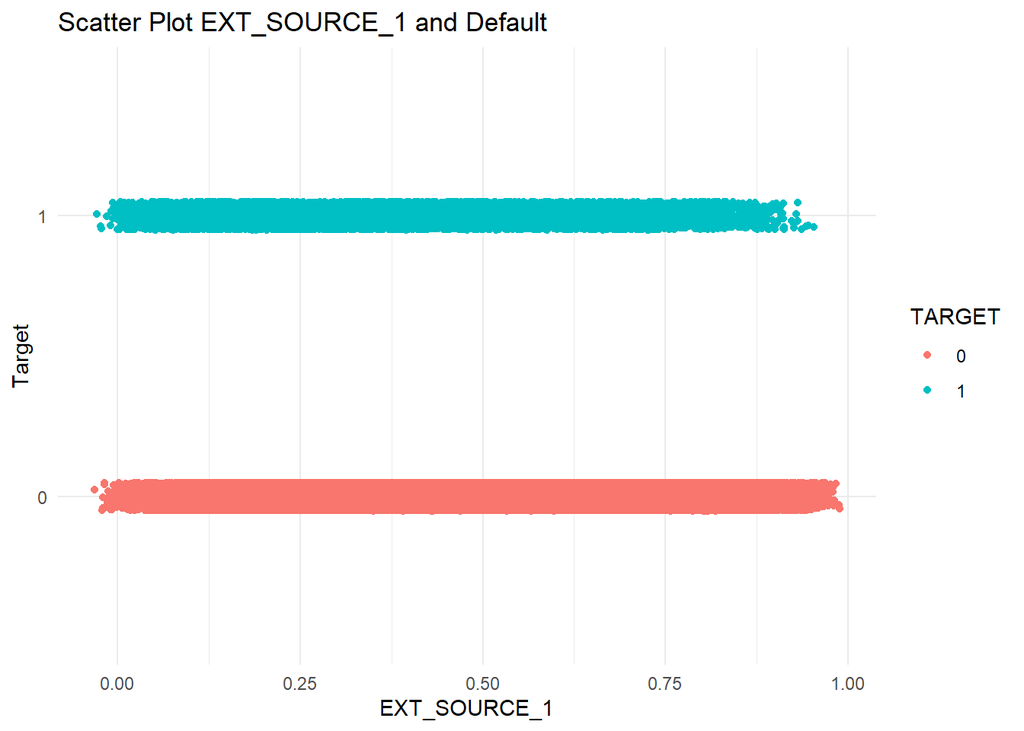

```r
# Ext_Source_1 vs. default scatterplot
homecredit_train %>%
  ggplot(aes(x = EXT_SOURCE_1, y = TARGET, color = TARGET)) +
  geom_jitter(height = 0.05, width = 0.05) +
  labs(x = "EXT_SOURCE_1", y = "Target") +
  theme_minimal() +
  ggtitle("Scatter Plot EXT_SOURCE_1 and Default")
```

The distribution of the credit score from the 1st external source is very normal. Because of this, we could impute missing data in this variable with the mean credit score.

## 6.5 Numeric Variable Exploration - Ext_Source_2

```r
# credit source 2 summary statistics
homecredit_train$EXT_SOURCE_2 %>%
  summary()
```

```
##    Min. 1st Qu.  Median    Mean 3rd Qu.    Max.    NA's
##  0.0000  0.3925  0.5660  0.5144  0.6636  0.8550     660
```

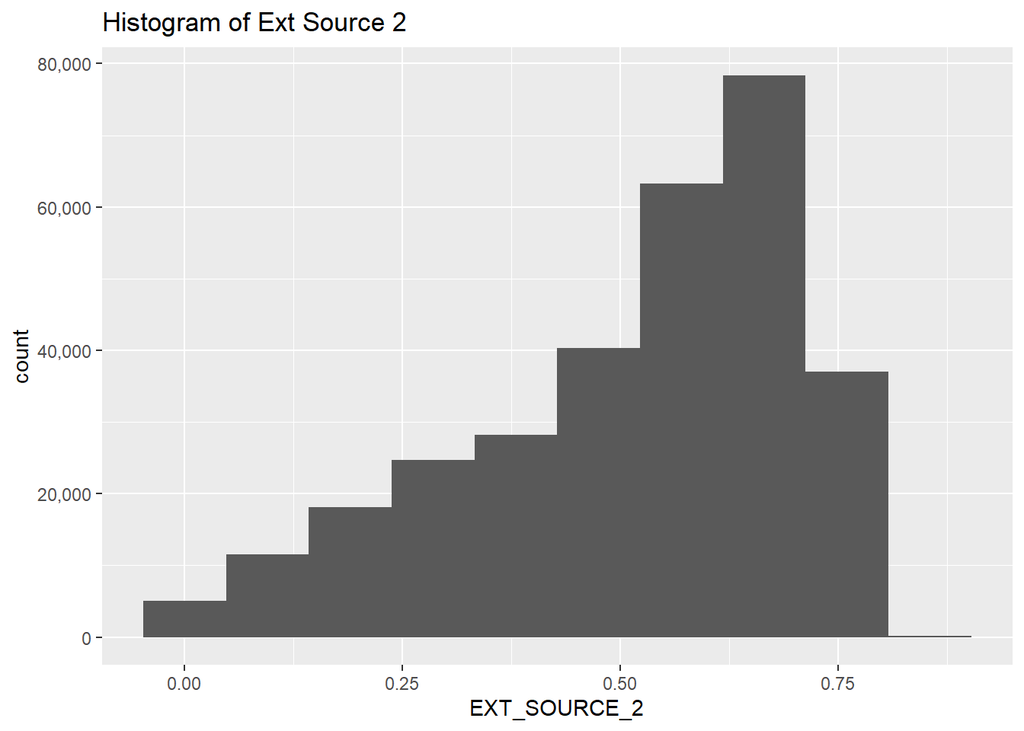

```r
# credit source 2 histogram
homecredit_train %>%
  ggplot(aes(x=EXT_SOURCE_2)) +
  geom_histogram(bins=10) +
  scale_x_continuous(labels = scales::comma) +
  scale_y_continuous(labels = scales::comma) +
  ggtitle('Histogram of Ext Source 2')
```

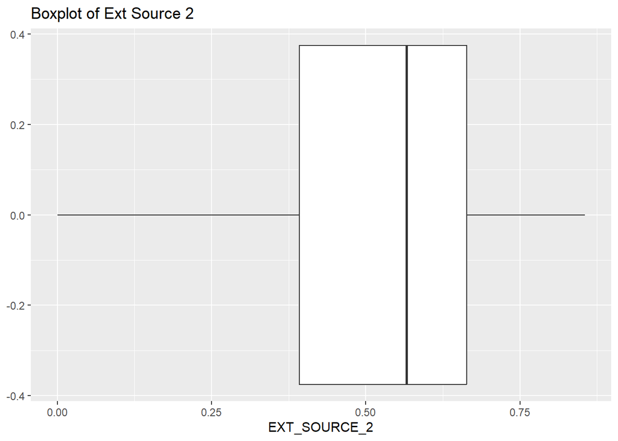

```r
# credit source 2 boxplot
homecredit_train %>%
  ggplot(aes(x=EXT_SOURCE_2)) +
  geom_boxplot() +
  scale_x_continuous(labels = scales::comma) +
  scale_y_continuous(labels = scales::comma) +
  ggtitle('Boxplot of Ext Source 2')
```

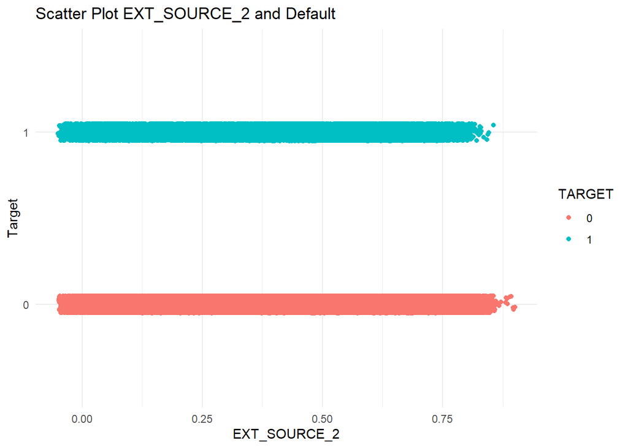

```r
# Ext_Source_2 vs. default scatterplot
homecredit_train %>%
  ggplot(aes(x = EXT_SOURCE_2, y = TARGET, color = TARGET)) +
  geom_jitter(height = 0.05, width = 0.05) +
  labs(x = "EXT_SOURCE_2", y = "Target") +
  theme_minimal() +
  ggtitle("Scatter Plot EXT_SOURCE_2 and Default")
```

The distribution of the credit score from the 2nd external source is left skewed. Because of this, we could impute missing data in this variable with the median credit score from this variable. However, there aren’t many missing entries so we could either omit these rows or replace the missing values with zero.

## 6.6 Numeric Variable Exploration - Ext_Source_3

```r
# credit source 3 summary statistics
homecredit_train$EXT_SOURCE_3 %>%
  summary()
```

```
##    Min. 1st Qu.  Median    Mean 3rd Qu.    Max.    NA's
##    0.00    0.37    0.54    0.51    0.67    0.90   60965
```

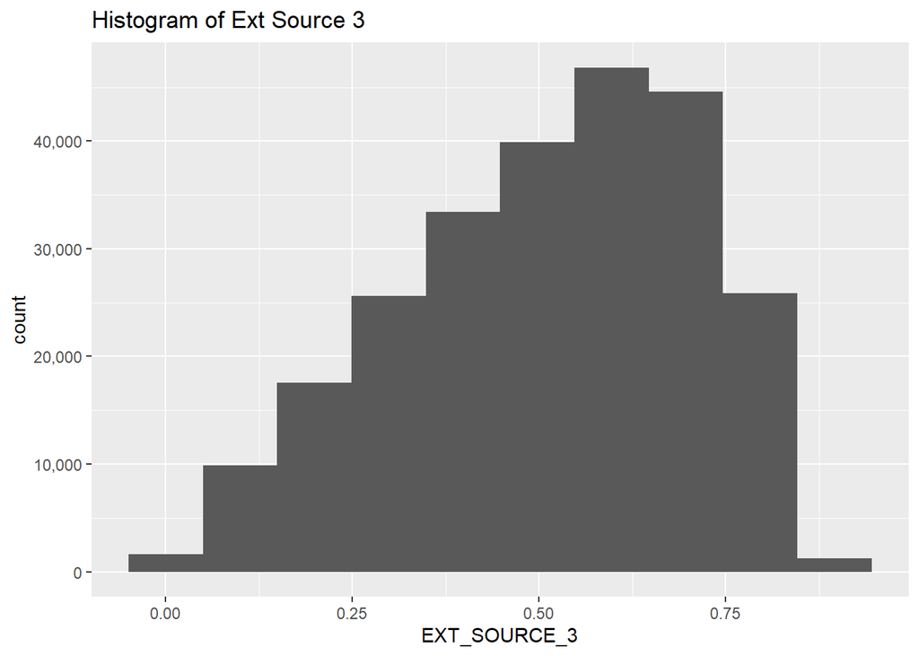

```r
# credit source 3 histogram
homecredit_train %>%
  ggplot(aes(x=EXT_SOURCE_3)) +
  geom_histogram(bins=10) +
  scale_x_continuous(labels = scales::comma) +
  scale_y_continuous(labels = scales::comma) +
  ggtitle('Histogram of Ext Source 3')
```

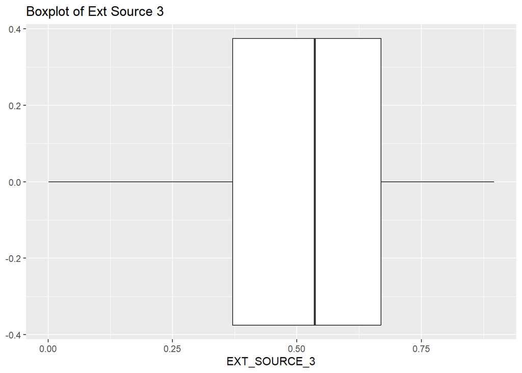

```r
# credit source 3 boxplot
homecredit_train %>%
  ggplot(aes(x=EXT_SOURCE_3)) +
  geom_boxplot() +
  scale_x_continuous(labels = scales::comma) +
  scale_y_continuous(labels = scales::comma) +
  ggtitle('Boxplot of Ext Source 3')
```

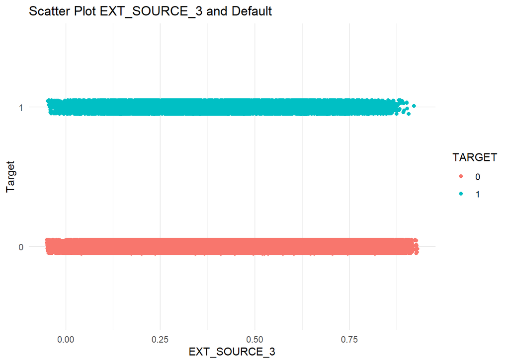

```r
# Ext_Source_3 vs. default scatterplot
homecredit_train %>%
  ggplot(aes(x = EXT_SOURCE_3, y = TARGET, color = TARGET)) +
  geom_jitter(height = 0.05, width = 0.05) +
  labs(x = "EXT_SOURCE_3", y = "Target") +
  theme_minimal() +
  ggtitle("Scatter Plot EXT_SOURCE_3 and Default")
```

The distribution of the credit score from the 3rd external source is also left skewed. Because of this, we could impute missing data in this variable with the median credit score from this variable. Since there are more missing entries than the 2nd external source variable, we would need to decide if we want to replace the missing values with a zero, the median, or omit those rows. However, if we omit the rows, we would lose a significant amount of our data.

# 7 Exploring Categorical Variables

## 7.1 Income Type and Target Variable

```r
# proportions of the target variable by income
homecredit_train %>% select(TARGET,NAME_INCOME_TYPE) %>% table() %>% prop.table() %>% round(2)
```

```
##       NAME_INCOME_TYPE
## TARGET Businessman Commercial associate Maternity leave Pensioner State servant
##      0        0.00                 0.22            0.00      0.17          0.07
##      1        0.00                 0.02            0.00      0.01          0.00
##       NAME_INCOME_TYPE
## TARGET Student Unemployed Working
##      0    0.00       0.00    0.47
##      1    0.00       0.00    0.05
```

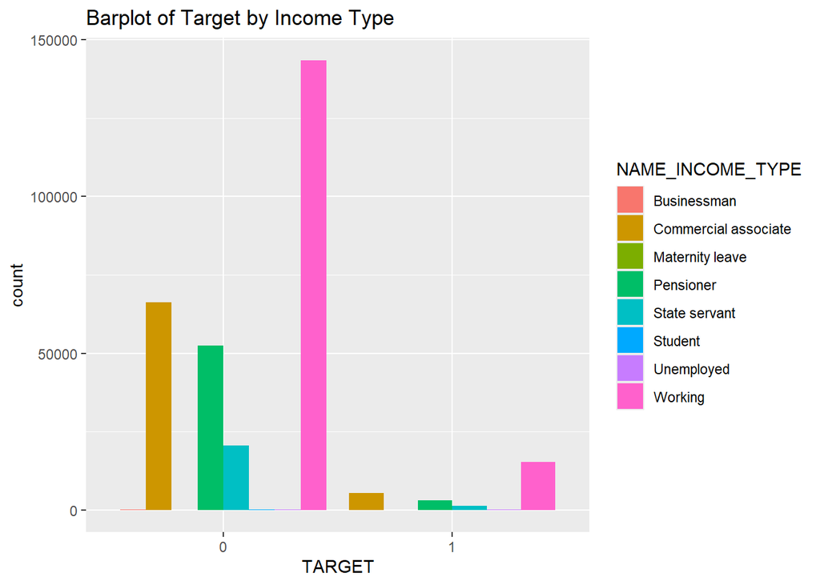

```r
# bar plot of the target by income
homecredit_train %>%
  ggplot() +
  geom_bar(aes(x=TARGET,fill=NAME_INCOME_TYPE),position="dodge") +
  ggtitle("Barplot of Target by Income Type")
```

The majority of those who defaulted were working “income type.” How do the income type, income amount, and loan amount variables do together in predicting default?

## 7.2 Education Type and Target Variable

```r
# proportions of the target variable by education type
homecredit_train %>% select(TARGET,NAME_EDUCATION_TYPE) %>% table() %>% prop.table() %>% round(2)
```

```
##       NAME_EDUCATION_TYPE
## TARGET Academic degree Higher education Incomplete higher Lower secondary
##      0            0.00             0.23              0.03            0.01
##      1            0.00             0.01              0.00            0.00
##       NAME_EDUCATION_TYPE
## TARGET Secondary / secondary special
##      0                          0.65
##      1                          0.06
```

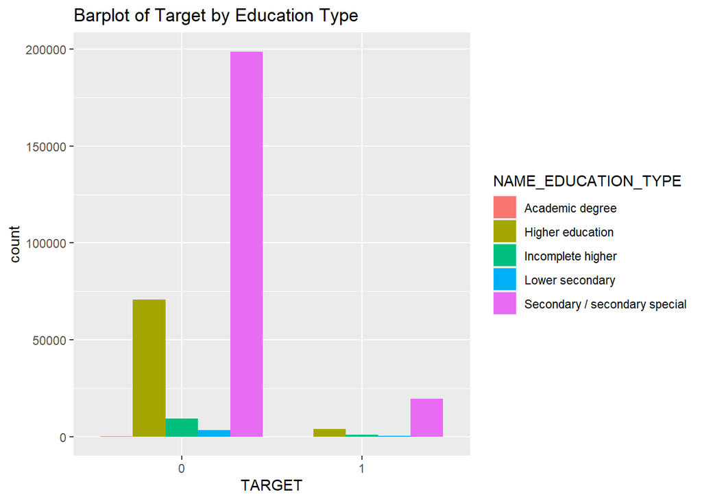

```r
# bar plot of the target by education type
homecredit_train %>%
  ggplot() +
  geom_bar(aes(x=TARGET,fill=NAME_EDUCATION_TYPE),position="dodge") +
  ggtitle("Barplot of Target by Education Type")
```

The majority of those who defaulted were had a secondary education. We could isolate the secondary education type and and identify which variables within those individuals can help us predict default.

## 7.3 Contract Type and Target Variable

```r
# proportions of the target variable by contract type
homecredit_train %>% select(TARGET,NAME_CONTRACT_TYPE) %>% table() %>% prop.table() %>% round(2)
```

```
##       NAME_CONTRACT_TYPE
## TARGET Cash loans Revolving loans
##      0       0.83            0.09
##      1       0.08            0.01
```

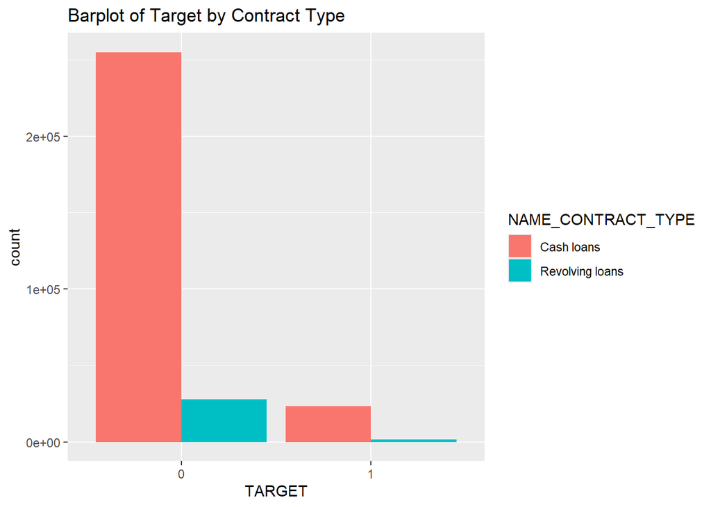

```r
# bar plot of the target by contract type
homecredit_train %>%
  ggplot() +
  geom_bar(aes(x=TARGET,fill=NAME_CONTRACT_TYPE),position="dodge") +
  ggtitle("Barplot of Target by Contract Type")
```

Most loans are cash loans and the revolving loans have very minimal defaults, indicating that this is likely not a useful predictor.

## 7.4 Car Ownership and Target Variable

```r
# proportions of the target variable by gender
homecredit_train %>% select(TARGET,FLAG_OWN_CAR) %>% table() %>% prop.table() %>% round(2)
```

```
##       FLAG_OWN_CAR
## TARGET    N    Y
##      0 0.60 0.32
##      1 0.06 0.02
```

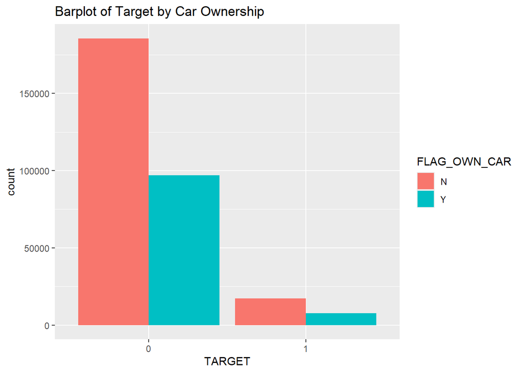

```r
# bar plot of the target by gender
homecredit_train %>%
  ggplot() +
  geom_bar(aes(x=TARGET,fill=FLAG_OWN_CAR),position="dodge") +
  ggtitle("Barplot of Target by Car Ownership")
```

The split between owns a car and does not own a car when compared to the two outcome groups does not have much of a difference. In other words, we don’t see a much higher proportion of those owning a car vs not owing a car in the default group compared to the no default group. This also implies that that this is likely not a useful predictor.

# 8 Handling NA Values for Train Data

```r
# replace missing credit score data with 0
homecredit_train_clean <- homecredit_train %>%
  mutate_at(vars(EXT_SOURCE_3, EXT_SOURCE_2,EXT_SOURCE_1), ~replace(., is.na(.), 0))

# remove columns with 20% or more NAs
homecredit_train_clean <- homecredit_train_clean %>%
  select_if(~ mean(is.na(.)) < .2)

# remove rows with any NA values
homecredit_train_clean <- na.omit(homecredit_train_clean)

# summary statistics of cleaned train data
homecredit_train_clean %>% summary()
```

```
##    SK_ID_CURR     TARGET           NAME_CONTRACT_TYPE CODE_GENDER  FLAG_OWN_CAR
##  Min.   :100002   0:244408   Cash loans     :240981   F  :175544   N:172653
##  1st Qu.:188983   1: 20490   Revolving loans: 23917   M  : 89350   Y: 92245
##  Median :278019                                       XNA:     4
##  Mean   :278123
##  3rd Qu.:367186
##  Max.   :456255
##
##  FLAG_OWN_REALTY  CNT_CHILDREN     AMT_INCOME_TOTAL      AMT_CREDIT
##  N: 82108        Min.   : 0.0000   Min.   :    26100   Min.   :  45000
##  Y:182790        1st Qu.: 0.0000   1st Qu.:   112500   1st Qu.: 273636
##                  Median : 0.0000   Median :   157500   Median : 521280
##                  Mean   : 0.4226   Mean   :   171174   Mean   : 607161
##                  3rd Qu.: 1.0000   3rd Qu.:   202500   3rd Qu.: 814041
##                  Max.   :19.0000   Max.   :117000000   Max.   :4050000
##
##   AMT_ANNUITY     AMT_GOODS_PRICE          NAME_TYPE_SUITE
##  Min.   :  1616   Min.   :  40500   Unaccompanied  :214831
##  1st Qu.: 16673   1st Qu.: 238500   Family         : 34343
##  Median : 25016   Median : 450000   Spouse, partner:  9601
##  Mean   : 27204   Mean   : 545404   Children       :  2775
##  3rd Qu.: 34749   3rd Qu.: 688500   Other_B        :  1464
##  Max.   :258026   Max.   :4050000                  :   951
##                                     (Other)        :   933
##              NAME_INCOME_TYPE                     NAME_EDUCATION_TYPE
##  Working             :136377   Academic degree              :   144
##  Commercial associate: 61507   Higher education             : 66052
##  Pensioner           : 47569   Incomplete higher            :  8550
##  State servant       : 19423   Lower secondary              :  3141
##  Student             :    15   Secondary / secondary special:187011
##  Businessman         :     4
##  (Other)             :     3
##             NAME_FAMILY_STATUS           NAME_HOUSING_TYPE
##  Civil marriage      : 24875   Co-op apartment    :   984
##  Married             :171484   House / apartment  :235960
##  Separated           : 17271   Municipal apartment:  9568
##  Single / not married: 37400   Office apartment   :  2275
##  Unknown             :     0   Rented apartment   :  3948
##  Widow               : 13868   With parents       : 12163
##
```

[output cut: 137 more lines]

```
##  Min.   :0.00000            Min.   : 0.0000           Min.   :  0.0000
##  1st Qu.:0.00000            1st Qu.: 0.0000           1st Qu.:  0.0000
##  Median :0.00000            Median : 0.0000           Median :  0.0000
##  Mean   :0.03442            Mean   : 0.2675           Mean   :  0.2657
##  3rd Qu.:0.00000            3rd Qu.: 0.0000           3rd Qu.:  0.0000
##  Max.   :8.00000            Max.   :27.0000           Max.   :261.0000
##
##  AMT_REQ_CREDIT_BUREAU_YEAR
##  Min.   : 0.000
##  1st Qu.: 0.000
##  Median : 1.000
##  Mean   : 1.901
##  3rd Qu.: 3.000
##  Max.   :25.000
##
```

# 9 Handling NA Values for Test Data

```r
# replace missing credit score data with 0
homecredit_test_clean <- homecredit_test %>%
  mutate_at(vars(EXT_SOURCE_3, EXT_SOURCE_2,EXT_SOURCE_1), ~replace(., is.na(.), 0))

# remove columns with 20% or more NAs
homecredit_test_clean <- homecredit_test_clean %>%
  select_if(~ mean(is.na(.)) < .2)

# remove rows with any NA values
homecredit_test_clean <- na.omit(homecredit_test_clean)

# summary statistics of cleaned train data
homecredit_test_clean %>% summary()
```

```
##    SK_ID_CURR           NAME_CONTRACT_TYPE CODE_GENDER FLAG_OWN_CAR
##  Min.   :100001   Cash loans     :42289    F:28954     N:27912
##  1st Qu.:188174   Revolving loans:  359    M:13694     Y:14736
##  Median :277513
##  Mean   :277673
##  3rd Qu.:367317
##  Max.   :456250
##
##  FLAG_OWN_REALTY  CNT_CHILDREN     AMT_INCOME_TOTAL    AMT_CREDIT
##  N:13153         Min.   : 0.0000   Min.   :  26942   Min.   :  45000
##  Y:29495         1st Qu.: 0.0000   1st Qu.: 112500   1st Qu.: 260640
##                  Median : 0.0000   Median : 157500   Median : 450000
##                  Mean   : 0.4008   Mean   : 181238   Mean   : 523828
##                  3rd Qu.: 1.0000   3rd Qu.: 225000   3rd Qu.: 675000
##                  Max.   :20.0000   Max.   :4410000   Max.   :2160000
##
##   AMT_ANNUITY     AMT_GOODS_PRICE          NAME_TYPE_SUITE
##  Min.   :  2295   Min.   :  45000   Unaccompanied  :34837
##  1st Qu.: 18041   1st Qu.: 225000   Family         : 5075
##  Median : 26231   Median : 409500   Spouse, partner: 1245
##  Mean   : 29496   Mean   : 469311                  :  820
##  3rd Qu.: 37436   3rd Qu.: 630000   Children       :  353
##  Max.   :180576   Max.   :2160000   Other_B        :  185
##                                     (Other)        :  133
##              NAME_INCOME_TYPE                    NAME_EDUCATION_TYPE
##  Businessman         :    1   Academic degree              :   36
##  Commercial associate: 9936   Higher education             :11242
##  Pensioner           : 8144   Incomplete higher            : 1470
##  State servant       : 3223   Lower secondary              :  375
##  Student             :    1   Secondary / secondary special:29525
##  Unemployed          :    0
##  Working             :21343
##             NAME_FAMILY_STATUS           NAME_HOUSING_TYPE
##  Civil marriage      : 3601    Co-op apartment    :  105
##  Married             :28688    House / apartment  :38391
##  Separated           : 2588    Municipal apartment: 1381
##  Single / not married: 5849    Office apartment   :  346
##  Widow               : 1922    Rented apartment   :  577
##                                With parents       : 1848
##
```

[output cut: 129 more lines]

```
##  Min.   :0.000000          Min.   :0.00000            Min.   :0.000000
##  1st Qu.:0.000000          1st Qu.:0.00000            1st Qu.:0.000000
##  Median :0.000000          Median :0.00000            Median :0.000000
##  Mean   :0.001806          Mean   :0.00279            Mean   :0.009309
##  3rd Qu.:0.000000          3rd Qu.:0.00000            3rd Qu.:0.000000
##  Max.   :2.000000          Max.   :2.00000            Max.   :6.000000
##
##  AMT_REQ_CREDIT_BUREAU_QRT AMT_REQ_CREDIT_BUREAU_YEAR
##  Min.   :0.000             Min.   : 0.000
##  1st Qu.:0.000             1st Qu.: 0.000
##  Median :0.000             Median : 2.000
##  Mean   :0.547             Mean   : 1.984
##  3rd Qu.:1.000             3rd Qu.: 3.000
##  Max.   :7.000             Max.   :17.000
##
```

# 10 Handling NA Values for Bureau Data

```r
# summary statistics of bureau data
bureau %>% summary()
```

```
##    SK_ID_CURR      SK_ID_BUREAU      CREDIT_ACTIVE       CREDIT_CURRENCY
##  Min.   :100001   Min.   :5000000   Active  : 630607   currency 1:1715020
##  1st Qu.:188867   1st Qu.:5463954   Bad debt:     21   currency 2:   1224
##  Median :278055   Median :5926304   Closed  :1079273   currency 3:    174
##  Mean   :278215   Mean   :5924434   Sold    :   6527   currency 4:     10
##  3rd Qu.:367426   3rd Qu.:6385681
##  Max.   :456255   Max.   :6843457
##
##   DAYS_CREDIT    CREDIT_DAY_OVERDUE  DAYS_CREDIT_ENDDATE DAYS_ENDDATE_FACT
##  Min.   :-2922   Min.   :   0.0000   Min.   :-42060.0    Min.   :-42023
##  1st Qu.:-1666   1st Qu.:   0.0000   1st Qu.: -1138.0    1st Qu.: -1489
##  Median : -987   Median :   0.0000   Median :  -330.0    Median :  -897
##  Mean   :-1142   Mean   :   0.8182   Mean   :   510.5    Mean   : -1017
##  3rd Qu.: -474   3rd Qu.:   0.0000   3rd Qu.:   474.0    3rd Qu.:  -425
##  Max.   :    0   Max.   :2792.0000   Max.   : 31199.0    Max.   :     0
##                                      NA's   :105553      NA's   :633653
##  AMT_CREDIT_MAX_OVERDUE CNT_CREDIT_PROLONG AMT_CREDIT_SUM
##  Min.   :        0      Min.   :0.00000    Min.   :        0
##  1st Qu.:        0      1st Qu.:0.00000    1st Qu.:    51300
##  Median :        0      Median :0.00000    Median :   125518
##  Mean   :     3825      Mean   :0.00641    Mean   :   354995
##  3rd Qu.:        0      3rd Qu.:0.00000    3rd Qu.:   315000
##  Max.   :115987185      Max.   :9.00000    Max.   :585000000
##  NA's   :1124488                           NA's   :13
##  AMT_CREDIT_SUM_DEBT AMT_CREDIT_SUM_LIMIT AMT_CREDIT_SUM_OVERDUE
##  Min.   : -4705600   Min.   :-586406      Min.   :      0
##  1st Qu.:        0   1st Qu.:      0      1st Qu.:      0
##  Median :        0   Median :      0      Median :      0
##  Mean   :   137085   Mean   :   6230      Mean   :     38
##  3rd Qu.:    40154   3rd Qu.:      0      3rd Qu.:      0
##  Max.   :170100000   Max.   :4705600      Max.   :3756681
##  NA's   :257669      NA's   :591780
##                         CREDIT_TYPE      DAYS_CREDIT_UPDATE  AMT_ANNUITY
##  Consumer credit              :1251615   Min.   :-41947.0   Min.   :        0
##  Credit card                  : 402195   1st Qu.:  -908.0   1st Qu.:        0
##  Car loan                     :  27690   Median :  -395.0   Median :        0
##  Mortgage                     :  18391   Mean   :  -593.8   Mean   :    15713
##  Microloan                    :  12413   3rd Qu.:   -33.0   3rd Qu.:    13500
##  Loan for business development:   1975   Max.   :   372.0   Max.   :118453424
##  (Other)                      :   2149                      NA's   :1226791
```

```r
# replace NAs with 0
bureau <- bureau %>%
  mutate_at(vars(DAYS_CREDIT_ENDDATE, DAYS_ENDDATE_FACT,AMT_CREDIT_MAX_OVERDUE,AMT_CREDIT_SUM, AMT_CREDIT_SUM_DEBT, AMT_CREDIT_SUM_LIMIT,AMT_ANNUITY), ~replace(., is.na(.), 0))

# summary statistics after handling NAs
bureau %>% summary()
```

```
##    SK_ID_CURR      SK_ID_BUREAU      CREDIT_ACTIVE       CREDIT_CURRENCY
##  Min.   :100001   Min.   :5000000   Active  : 630607   currency 1:1715020
##  1st Qu.:188867   1st Qu.:5463954   Bad debt:     21   currency 2:   1224
##  Median :278055   Median :5926304   Closed  :1079273   currency 3:    174
##  Mean   :278215   Mean   :5924434   Sold    :   6527   currency 4:     10
##  3rd Qu.:367426   3rd Qu.:6385681
##  Max.   :456255   Max.   :6843457
##
##   DAYS_CREDIT    CREDIT_DAY_OVERDUE  DAYS_CREDIT_ENDDATE DAYS_ENDDATE_FACT
##  Min.   :-2922   Min.   :   0.0000   Min.   :-42060.0    Min.   :-42023.0
##  1st Qu.:-1666   1st Qu.:   0.0000   1st Qu.: -1074.0    1st Qu.: -1089.0
##  Median : -987   Median :   0.0000   Median :  -237.0    Median :  -352.0
##  Mean   :-1142   Mean   :   0.8182   Mean   :   479.1    Mean   :  -641.8
##  3rd Qu.: -474   3rd Qu.:   0.0000   3rd Qu.:   389.0    3rd Qu.:     0.0
##  Max.   :    0   Max.   :2792.0000   Max.   : 31199.0    Max.   :     0.0
##
##  AMT_CREDIT_MAX_OVERDUE CNT_CREDIT_PROLONG AMT_CREDIT_SUM
##  Min.   :        0      Min.   :0.00000    Min.   :        0
##  1st Qu.:        0      1st Qu.:0.00000    1st Qu.:    51300
##  Median :        0      Median :0.00000    Median :   125518
##  Mean   :     1319      Mean   :0.00641    Mean   :   354992
##  3rd Qu.:        0      3rd Qu.:0.00000    3rd Qu.:   315000
##  Max.   :115987185      Max.   :9.00000    Max.   :585000000
##
##  AMT_CREDIT_SUM_DEBT AMT_CREDIT_SUM_LIMIT AMT_CREDIT_SUM_OVERDUE
##  Min.   : -4705600   Min.   :-586406      Min.   :      0
##  1st Qu.:        0   1st Qu.:      0      1st Qu.:      0
##  Median :        0   Median :      0      Median :      0
##  Mean   :   116506   Mean   :   4082      Mean   :     38
##  3rd Qu.:     1976   3rd Qu.:      0      3rd Qu.:      0
##  Max.   :170100000   Max.   :4705600      Max.   :3756681
##
##                         CREDIT_TYPE      DAYS_CREDIT_UPDATE  AMT_ANNUITY
##  Consumer credit              :1251615   Min.   :-41947.0   Min.   :        0
##  Credit card                  : 402195   1st Qu.:  -908.0   1st Qu.:        0
##  Car loan                     :  27690   Median :  -395.0   Median :        0
##  Mortgage                     :  18391   Mean   :  -593.8   Mean   :     4482
##  Microloan                    :  12413   3rd Qu.:   -33.0   3rd Qu.:        0
##  Loan for business development:   1975   Max.   :   372.0   Max.   :118453424
##  (Other)                      :   2149
```

# 11 Join Application and Bureau Data

```r
# aggregate bureau data by current ID, number of loans, average loan amount, average days overdue, and currency
bureau_aggregated <- bureau %>%
  group_by(SK_ID_CURR) %>%
  summarise(total_loans = n(),
            avg_loan_amount = mean(AMT_CREDIT_SUM, na.rm = TRUE),
            avg_days_overdue = mean(CREDIT_DAY_OVERDUE),
            currency = CREDIT_CURRENCY)

# return one row per ID
bureau_aggregated <- distinct(bureau_aggregated)

# join train and bureau data
train_bureau <- left_join(homecredit_train_clean, bureau_aggregated, by = "SK_ID_CURR")

# remove rows with any NA values
train_bureau <- na.omit(train_bureau)

# view aggregated data summary
bureau_aggregated %>% summary()
```

```
##    SK_ID_CURR      total_loans      avg_loan_amount     avg_days_overdue
##  Min.   :100001   Min.   :  1.000   Min.   :        0   Min.   :   0.0000
##  1st Qu.:188883   1st Qu.:  2.000   1st Qu.:   104213   1st Qu.:   0.0000
##  Median :277921   Median :  4.000   Median :   198066   Median :   0.0000
##  Mean   :278059   Mean   :  5.626   Mean   :   385825   Mean   :   0.9629
##  3rd Qu.:367206   3rd Qu.:  8.000   3rd Qu.:   400355   3rd Qu.:   0.0000
##  Max.   :456255   Max.   :116.000   Max.   :198072344   Max.   :2776.0000
##        currency
##  currency 1:305773
##  currency 2:   970
##  currency 3:   157
##  currency 4:    10
##
##
```

# 12 Explore Target Variable and Accuracy for Joined Data

```r
# counts of default and no default observations
train_bureau %>% pull(TARGET) %>% table()
```

```
## .
##      0      1
## 242976  20379
```

```r
# proportions of default and no default observations
train_bureau %>% pull(TARGET) %>% table() %>% prop.table() %>% round(2)
```

```
## .
##    0    1
## 0.92 0.08
```

We still have the same target variable split as our original dataset, implying that we have not removed too much data where our outcome variable is affected, leading us to not be able to further explore our data or make any predictions.

# 13 Exploring Numeric Variables on Joined Data

## 13.1 Correlations

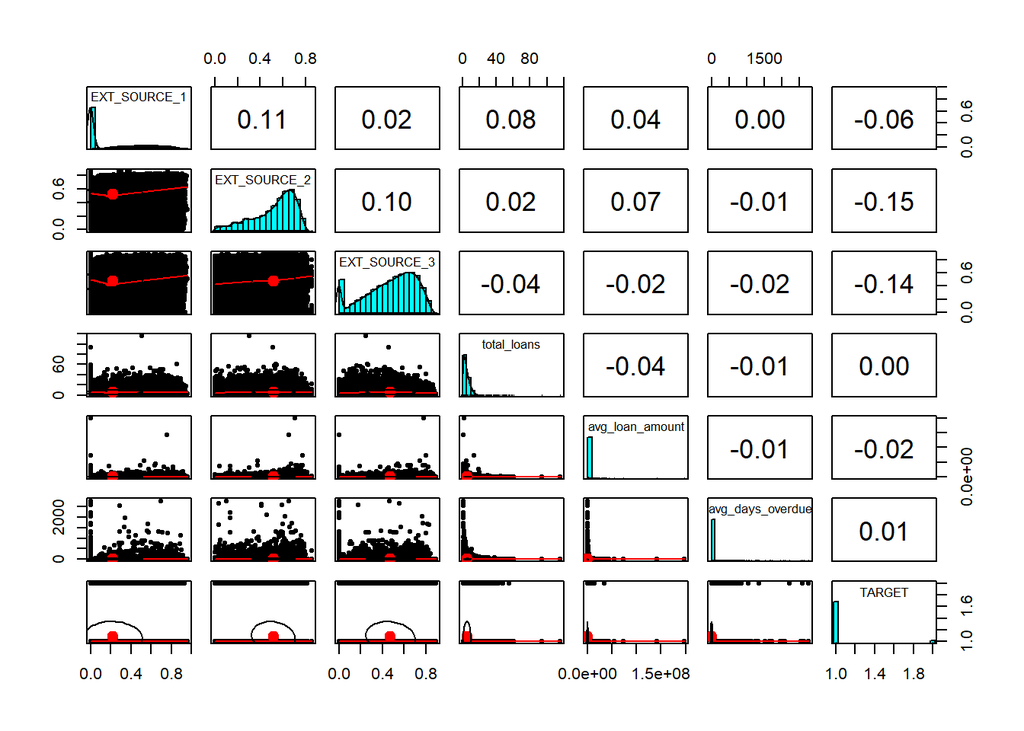

```r
# visual of correlations for some numeric variables with respect to the target variable
train_bureau %>%
  select(EXT_SOURCE_1,EXT_SOURCE_2,EXT_SOURCE_3, total_loans, avg_loan_amount, avg_days_overdue, TARGET) %>%
  pairs.panels()
```

## 13.2 Numeric Variable Exploration - Total Loans

```r
# total loans summary statistics
train_bureau$total_loans %>%
  summary()
```

```
##    Min. 1st Qu.  Median    Mean 3rd Qu.    Max.
##   1.000   2.000   4.000   5.578   8.000 116.000
```

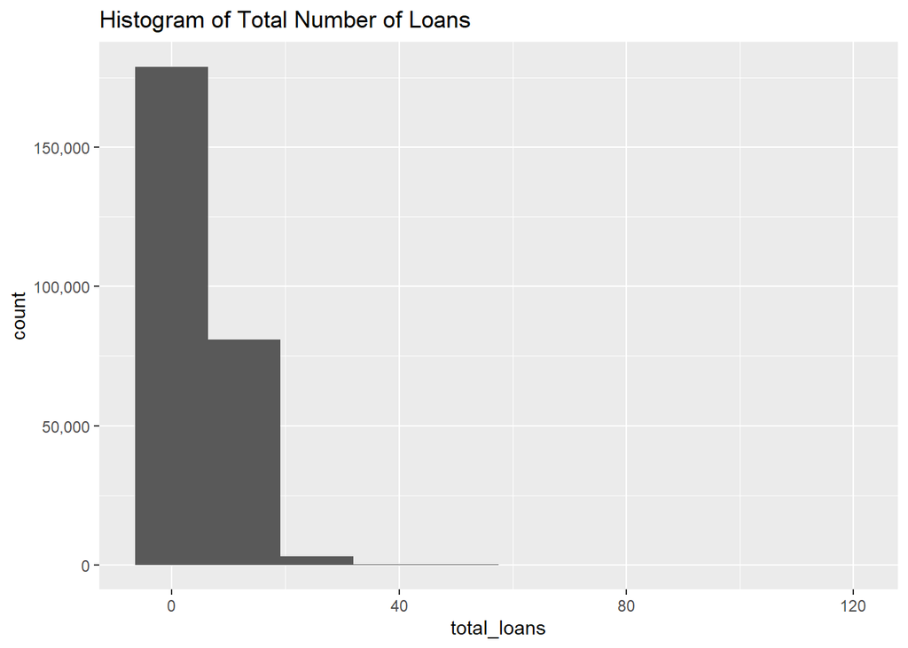

```r
# total loans histogram
train_bureau %>%
  ggplot(aes(x=total_loans)) +
  geom_histogram(bins=10) +
  scale_x_continuous(labels = scales::comma) +
  scale_y_continuous(labels = scales::comma) +
  ggtitle('Histogram of Total Number of Loans')
```

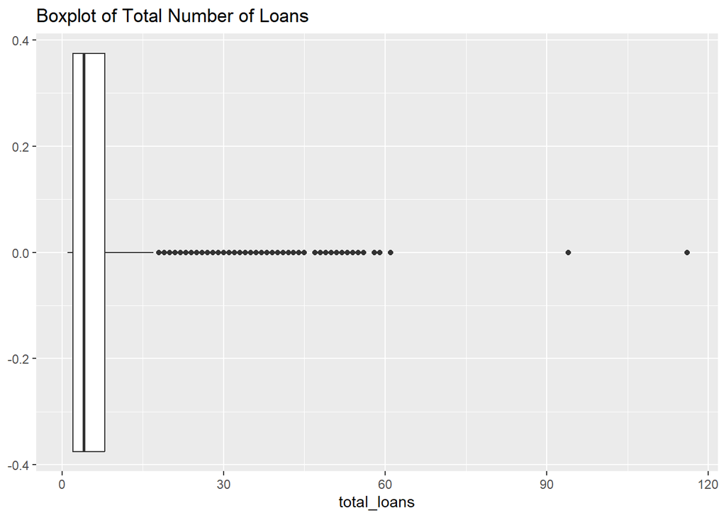

```r
# total loans boxplot
train_bureau %>%
  ggplot(aes(x=total_loans)) +
  geom_boxplot() +
  scale_x_continuous(labels = scales::comma) +
  scale_y_continuous(labels = scales::comma) +
  ggtitle('Boxplot of Total Number of Loans')
```

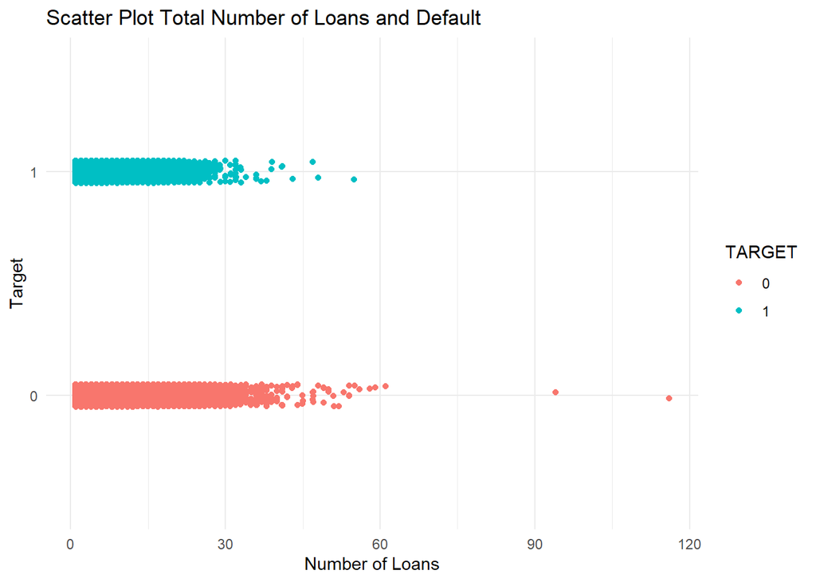

```r
# average loan amount vs. default scatterplot
train_bureau %>%
  ggplot(aes(x = total_loans, y = TARGET, color = TARGET)) +
  geom_jitter(height = 0.05, width = 0.05) +
  labs(x = "Number of Loans", y = "Target") +
  theme_minimal() +
  ggtitle("Scatter Plot Total Number of Loans and Default")
```

The spread of the total number of loans an individual has is very similar between the default and no default group, implying that the amount of loans someone has had, likely does not indicate if they are capable of repayment or not.

## 13.3 Numeric Variable Exploration - Average Loan Amouunt

```r
# average loan amount summary statistics
train_bureau$avg_loan_amount %>%
  summary()
```

```
##      Min.   1st Qu.    Median      Mean   3rd Qu.      Max.
##         0    103814    196333    382838    396534 198072344
```

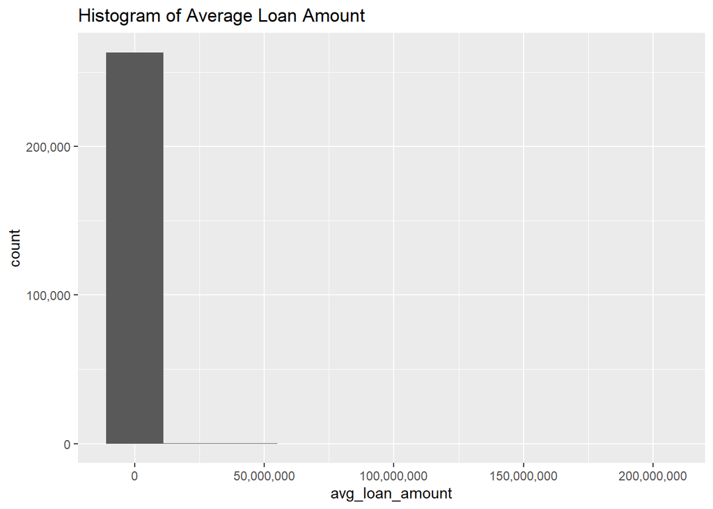

```r
# average loan amount histogram
train_bureau %>%
  ggplot(aes(x=avg_loan_amount)) +
  geom_histogram(bins=10) +
  scale_x_continuous(labels = scales::comma) +
  scale_y_continuous(labels = scales::comma) +
  ggtitle('Histogram of Average Loan Amount')
```

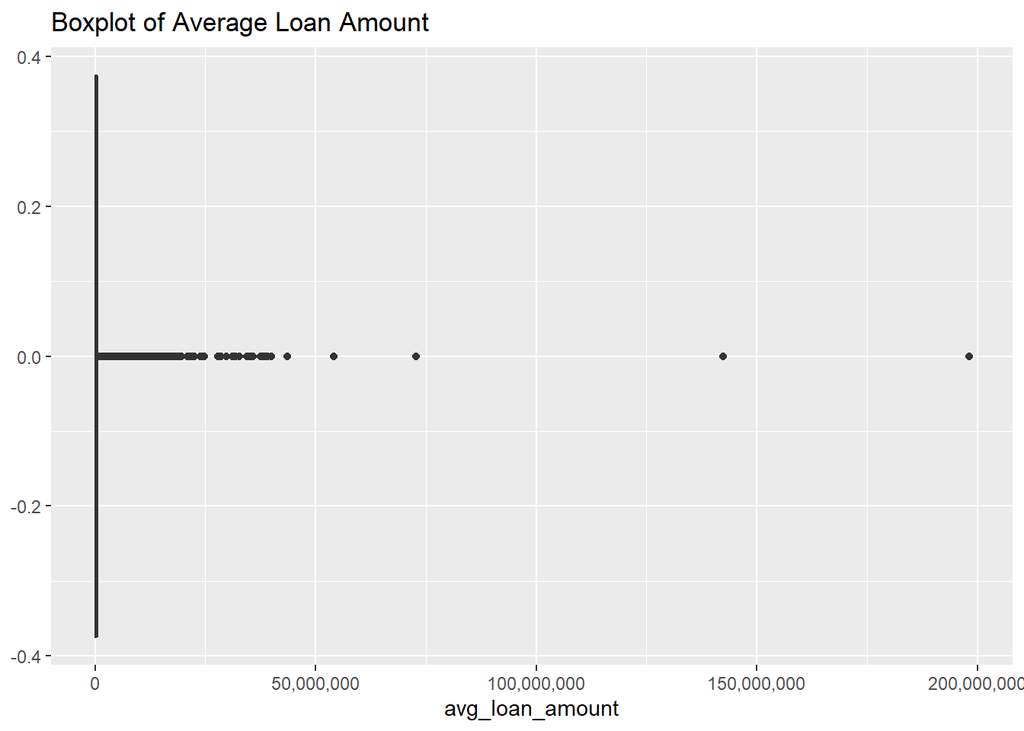

```r
# average loan amount boxplot
train_bureau %>%
  ggplot(aes(x=avg_loan_amount)) +
  geom_boxplot() +
  scale_x_continuous(labels = scales::comma) +
  scale_y_continuous(labels = scales::comma) +
  ggtitle('Boxplot of Average Loan Amount')
```

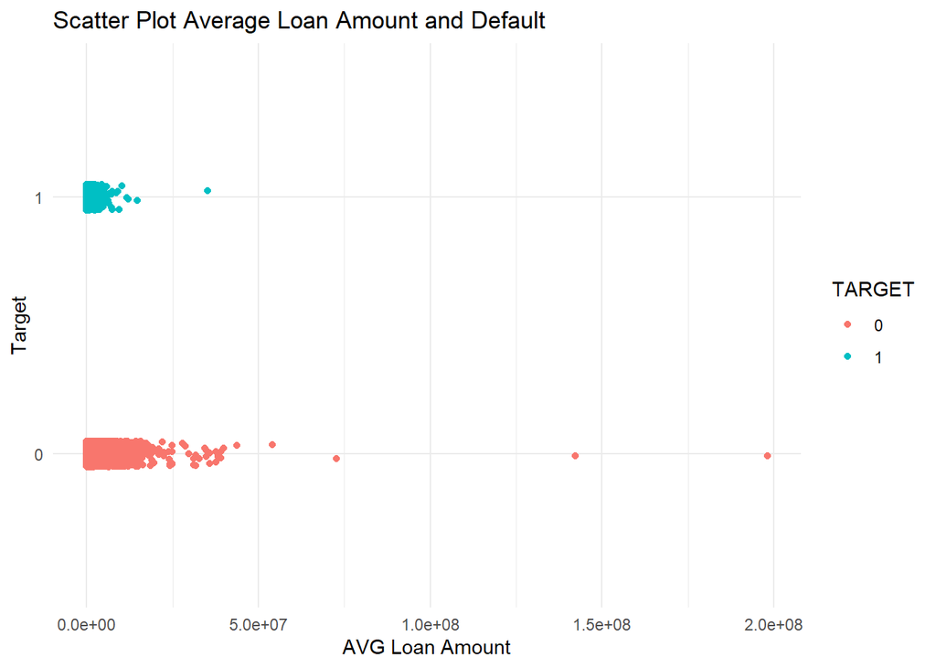

```r
# average loan amount vs. defualt scatterplot
train_bureau %>%
  ggplot(aes(x = avg_loan_amount, y = TARGET, color = TARGET)) +
  geom_jitter(height = 0.05, width = 0.05) +
  labs(x = "AVG Loan Amount", y = "Target") +
  theme_minimal() +
  ggtitle("Scatter Plot Average Loan Amount and Default")
```

The scatterplot using the average loan amount data from the bureau data compared to the training data is very similar, where those who default received a much lower loan amount, whereas those who don’t default are much more spread out across various loan amounts. We might consider using loan amount along with other variables to help in predicting default.

# 14 Results

Overall, there is a lot of data that will likely not help with predicting loan default. There are a handful of values that seem very large and incorrect, not just an outlier. When we look at the bureau data, we see different currencies which could explain these large values. However, the data does not indicate the currency, just “type 1”, “type 2”, etc. so we aren’t able to do a currency conversion. In this case, we may need to decide if we need to exclude these entries from the data set because it could be affecting potential predictor variables. Some variables I have identified as potential predictors are the external credit score sources having the strongest relationship with the target variable. Other potential predictors include the loan amount, an individuals income, employment type, and education type. We might want to include interaction terms on loan amount and income, or education type and loan amount. Interaction terms will be important in the modeling step of this project in order to determine the best predictors.